# Investigation of the waste separation knowledge and behavior among Zurich’s students

Capstone Project for the lecture ‘Research Beyond the Lab’ FS24

Author

Affiliation

Sven Prinz

[ETH Zurich](https://ethz.ch/de.html)

Published

June 6, 2024

Abstract

This study identifies students’ knowledge and availability of waste separation options on their campus as well as their willingness to walk for appropriate separation. Consequentially, possible measures are proposed to improve the waste separation at Zurich’s universities.

```r
library(tidyverse)
library(ggthemes)
library(ggridges)
library(gt)
library(gtsummary)
library(knitr)
library(DT)
```

```r
data_avail_wtw <- read_rds(here::here("data/processed/01-data_avail_wtw.rds"))
open_answers <- read_rds(here::here("data/processed/02-open_answers.rds"))
```

# Introduction

According to the SDG Report 2023 Sachs et al. (2023), more than 80% of the OECD countries have major challenges remaining in the sector of SDG 12 - Responsible consumption and production. Among them is Switzerland, despite being ranked number 15 out of 166 countries in the overall country ranking, with SDG 12 among its worst categories. Furthermore, the municipal solid waste production is estimated to increase in future years without taking urgent measures, and must be balanced out by an improved recycling in Switzerland and the world. (Programme & Association, 2024). This is a matter in which different players have an important role: governments, producers, the waste management sector, and the consumers. (Programme & Association, 2024)

The goal of this research is to not only look at the players separately, but to affect the cooperation between the government (here, the universities of Zurich) and the consumers (the students).

# Methods

To investigate the status and possible areas of improvement, the behavior and knowledge of Zurich’s students regarding waste separation was examined by the utilization of a survey.[^1]

This survey was then distributed in Whatsapp group chats, among friends, as well as random students on the campus. It contained demographic data, like the respondent’s main institution, their main campus, and level of studies. Furthermore, for many different waste types, multiple choice questions determined the student’s knowledge about their location and their need for such, as well as how far they would be willing to walk to dispose their waste in the designated bin for separation (produced during the time on campus) from the location it is produced before disposing it in the residual waste instead.

All mentioned waste types are already available on campus for separation.

# Results

In the sections below, the findings regarding student’s knowledge about separation availability, their waste separation behavior, and suggestions for improvement are portrayed.

## Availability of separation options

As seen in Figure 1 , the students’ awareness regarding the placement of separation options drastically differs between waste types. As expected, often used/produced waste types, like residual waste, pet, paper, and aluminum cans enjoy a larger awareness. Outliers for this trend are organic waste and other plastics which seem to have a large, unmet demand.  
To improve readability, the students’ responses are abbreviated by acronyms (see Table 1 for their meaning). Students who selected “No answer” are excluded in this section.

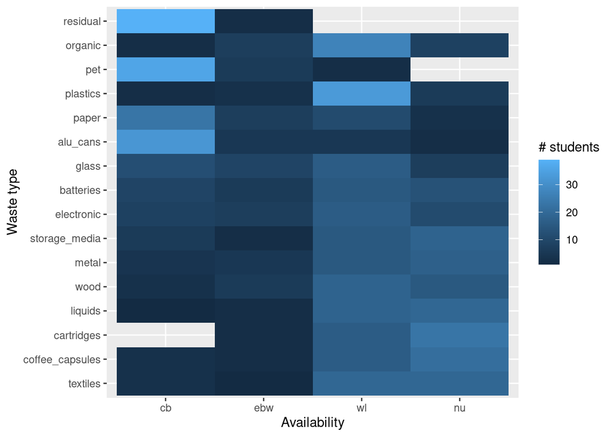

Figure 1: Results of survey, student’s answers to waste separation availability. (The meaning of the acronyms for the availability are explained in Table 1.)

```r
fig_avail_response <- data_avail_wtw |>
  filter(avail_resp_short != "noa") |>
  count(waste_type, avail_resp_short)

fig_avail_response |>
  ggplot(aes(x = avail_resp_short, y = fct_rev(waste_type))) +  # https://www.perplexity.ai/search/When-using-ggplot-.9PkPLwERA2BJyVcRre66g
  geom_tile(aes(fill = n)) +
  labs(x = "Availability",
       y = "Waste type",
       fill = "# students")

write_csv(fig_avail_response, here::here("data/final/fig-avail-response.csv"))
```

```r
unique_acronyms <- tibble(
  acronym = c("cb", "ebw", "wl", "nu"),
  meaning = c("I know where a bin is located nearby.",
              "I know it exists but I am not sure where.",
              "I do not know of any but I would like for it to be available.",
              "I do not know any and I would not use it.")
  )

unique_acronyms |>
  gt() |>
  cols_label(acronym = "Acronym", meaning = "Meaning") |>
  opt_stylize(style = 1)
write_csv(unique_acronyms, here::here("data/final/tbl-acro-meaning.csv"))
```

Table 1: Description of the acronyms for availability.

| Acronym | Meaning |
| --- | --- |
| cb | I know where a bin is located nearby. |
| ebw | I know it exists but I am not sure where. |
| wl | I do not know of any but I would like for it to be available. |
| nu | I do not know any and I would not use it. |

The necessity to improve information about the separation options can be seen more clearly, when combining the students that know of the existence but are not sure where, with the students that do not know the option exists but would like to have it (see Table 2). The finding suggests that many waste types, especially plastics and organic waste, lack knowledge of their locations.

```r
tbl_avail_response <- data_avail_wtw |>
  group_by(waste_type) |>
  count(waste_type, avail_resp_short) |>
  ungroup() |>
  pivot_wider(names_from = avail_resp_short,
              values_from = n,
              values_fill = 0) |>
  select(-noa) |>
  mutate(total_answers = cb + ebw + wl + nu) |>
  mutate(known_percent = cb / total_answers*100) |>
  mutate(unknown_percent = (ebw + wl) / total_answers *100) |>
  mutate(unused_percent = nu / total_answers *100) |>
  select(waste_type, total_answers, known_percent, unknown_percent, unused_percent)

tbl_avail_response |>
  gt() |>
  tab_header(title = "Percentages of replies for (summed up) categories.") |>
  cols_label(waste_type = "Waste type",
             total_answers = "Tot # of replies",
             known_percent = "Percentage of replies stating cb [%]",
             unknown_percent = "Percentage of replies stating ebw or wl [%]",
             unused_percent = "Percentage of replies stating nu [%]") |>
  fmt_number(columns = c(total_answers, known_percent,
                         unknown_percent, unused_percent ),
             decimals = 1) |>
  fmt_number(columns = total_answers, decimals = 0) |>
  opt_stylize(style = 1)
  write_csv(tbl_avail_response, here::here("data/final/tbl-avail-response.csv"))
```

Table 2: The answers provided on the survey and statistical data.

Percentages of replies for (summed up) categories.

| Waste type | Tot # of replies | Percentage of replies stating cb [%] | Percentage of replies stating ebw or wl [%] | Percentage of replies stating nu [%] |
| --- | --- | --- | --- | --- |
| residual | 41 | 95.1 | 4.9 | 0.0 |
| organic | 44 | 4.5 | 77.3 | 18.2 |
| pet | 44 | 81.8 | 18.2 | 0.0 |
| plastics | 44 | 4.5 | 81.8 | 13.6 |
| paper | 44 | 52.3 | 40.9 | 6.8 |
| alu_cans | 44 | 72.7 | 22.7 | 4.5 |
| glass | 44 | 27.3 | 56.8 | 15.9 |
| batteries | 43 | 20.9 | 48.8 | 30.2 |
| electronic | 42 | 19.0 | 54.8 | 26.2 |
| storage_media | 41 | 14.6 | 41.5 | 43.9 |
| metal | 41 | 9.8 | 48.8 | 41.5 |
| wood | 42 | 7.1 | 57.1 | 35.7 |
| liquids | 40 | 2.5 | 50.0 | 47.5 |
| cartridges | 41 | 0.0 | 43.9 | 56.1 |
| coffee_capsules | 42 | 7.1 | 42.9 | 50.0 |
| textiles | 42 | 7.1 | 47.6 | 45.2 |

## Willingness to walk

Regarding how far students would be willing to walk to dispose their waste in the designated bin for separation (produced during the time on campus) from the location it is produced before disposing it in the residual waste instead, coincides well the the expectation prior to the conducted survey. Figure 2 shows that students’ williingness to cover a distance for disposal correlates with the frequency of production. The most common waste types organic, pet, other plastics, paper, and aluminum cans show a median much closer to their site of production than less common waste types.[^2]

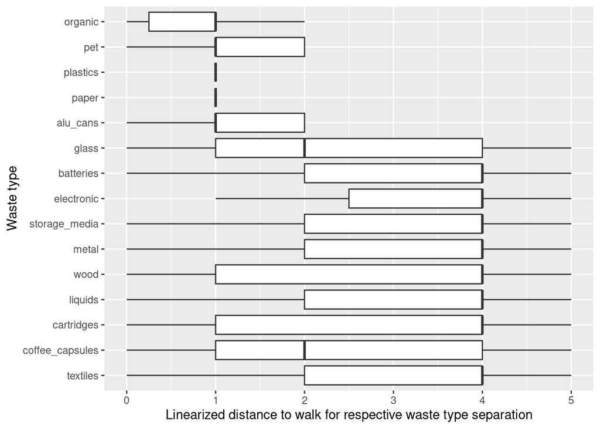

Figure 2: Boxplot of the willingness to walk for appropriate separation on campus.

```r
fig_wtw_response <- data_avail_wtw |>
  filter(!is.na(wtw_resp_nr)) #remove residual waste and "No answer" responses

fig_wtw_response |>
  ggplot(aes(x = wtw_resp_nr, y = fct_rev(waste_type))) +
  geom_boxplot(outlier.shape = NA) +
  labs(x = "Linearized distance to walk for respective waste type separation",
       y = "Waste type")

write_csv(fig_wtw_response, here::here("data/final/fig-wtw-response.csv"))
```

## Improvement suggestions

Lastly, the questioned individuals had the option to finish the survey with possible improvements. These proposals are listed in Table 3 .

```r
tbl_improvements <- open_answers |>
  select(improvements) |>
  filter(!(is.na(improvements)))

tbl_improvements |>
  gt() |>
  tab_header(title = "Improvements proposed by students.") |>
  cols_label(improvements = " ") |>
  opt_stylize(style = 1)
write_csv(tbl_improvements, here::here("data/final/tbl-improvements.csv"))
```

Table 3: Proposed improvements (open answers).

Improvements proposed by students.

| Make the information about where to find bins for separation more accessible. I do not find anything on the ETH website. |
| --- |
| That I am able to separate on the campus. I think that is not possible at my university. |
| more aluminium can bins! please, cannot bother walking around campus with empty can after a drink. should be as common as PET collection points. |
| Definitely more possibilities for cardboard and paper collection as well as glass. At least one known bin in each building but more preferably on each floor, especially for paper and cardboard. One kn… |
| definitely add organic waste bins (like on the Hönggerberg) |
| less waste production and less combined materials |
| Adding pictures to the waste bins to give visual clues on how to separate the waste. |
| Please don’t use the annoying sbb trashcan which close and you have push open with your hand to put something in, this makes me not want to separate waste and just trow it all in a open bin |
| Some waste bins have a spring-loaded lid that has to be pushed inward to be opened. Often people push on the lid with the trash they want to discard because they don‘t want to touch it. This can leave… |
| A note on some bins where the nearest collection point is for less common waste e.g. like the one in HG D floor |

Furthermore, the addition of the opportunity to recycle different 3D printer filament types has been proposed.

# Conclusions

Despite its small sample size, this study has already shown possible measures to improve the waste separation process at Zurich’s universities, which are:

- Increase the awareness of waste separation options for all waste types (e.g., by a recycling finder as proposed by a student)
- Matching the students’ willingness to walk by providing sufficient numbers of waste bins

By implementing the above specified measures, the total amount of municipal solid waste that is separated and recycled can be increased in the future, through mutual efforts by both, universities and students.

As a next step, the sample size of this study could be increased to enhance its value. This would even make a division into the different institutions possible, improving the efficiency of measures.

However, improving the waste separation only solves part of the problem. To reach the full potential in terms of saving energy, CO<sub>2</sub> emissions and conserving resources, more specific separating and a standardized design of products are necessary. (Klotz, 2022)

## References

Klotz, M. (2022). *Plastikrecycling soll kein Selbstzweck sein*. https://ethz.ch/de/news-und-veranstaltungen/eth-news/news/2022/02/plastikrecycling-soll-kein-selbstzweck-sein.html.

Programme, U. N. E., & Association, I. S. W. (2024). *Global Waste Management Outlook 2024 - Beyond an age of waste: Turning Rubbish into a Resource*. United Nations Environment Programme. https://doi.org/https://wedocs.unep.org/xmlui/handle/20.500.11822/44939

Sachs, J. D., Lafortune, G., Fuller, G., & Drumm, E. (2023). *Implementing the SDG Stimulus. Sustainable Development Report 2023: Sustainable Development Report 2023*. Dublin University Press. https://doi.org/10.25546/102924

## Footnotes

[^1]: The survey can be found here: https://forms.gle/P4ncgdWujPUFnryU9
[^2]: Replies stating “No answer” has been excluded from the displayed data again.